# Example Topics Documents

Tim König

2023-02-16

# Model: Clustering over full period, document level, pmi-weighted, clustered via Leiden algorithm (CPM with Resolution Parameter 0.3)

```
Only Printing Topics with at least 1% Topic Proportion: 18 out of 104 Topics.
```

```
 Only one Term in Topic 11. Returning Document Term Frequency instead of Page Rank.

 Only one Term in Topic 32. Returning Document Term Frequency instead of Page Rank.
```

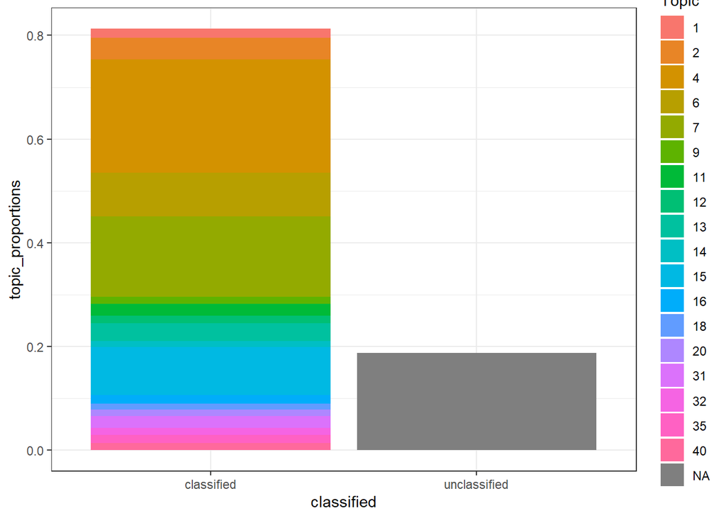

# Topic: 4

## Top Terms: Schacht, Bürgerhand, Ansiedlung, Aloys, Wobben, Windkraftanlage, Energiegenossenschaften, Kleimann, Drerup, Zäsur, Dumte, Münsterland, Sprengel, Teilhaber, GmbH., Hecke, Baugenehmigungsantrag, bodenlos, Wessen, gelten

## Topic Proportion: 22%

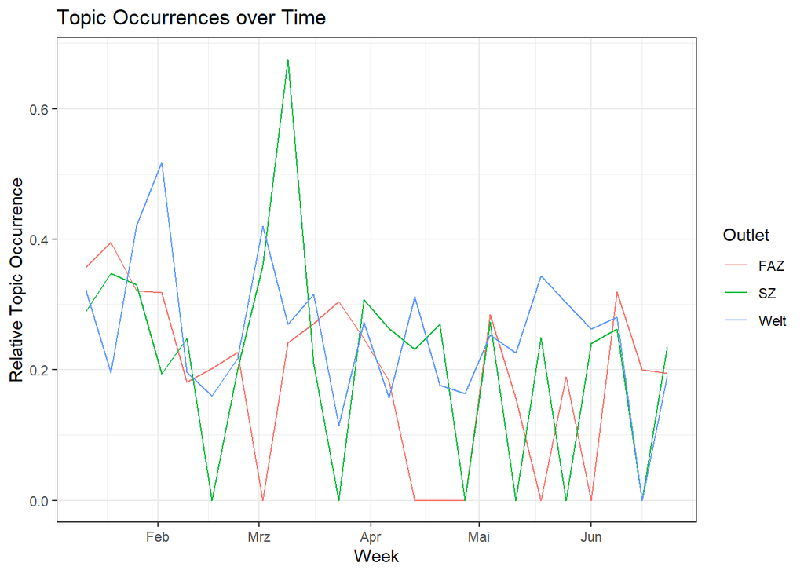

*Page Rank of Document: 0.03721502*

*Outlet: Welt*

**Vergiftetes Lob für Gabriels „Neustart“**

*Wirtschaftsminister Sigmar Gabriel arbeitet am „Neustart“ der Energiewende. Bislang heimst er Lob dafür ein. Doch es ist vergiftet. Den Schulterklopfern geht es nur um ihre Interessen.*

*Page Rank of Document: 0.02517065*

*Outlet: SZ*

**“Eine unsichtbare Energiewende gibt es nicht”**

*Dezentral und bürgernah - nur so wird die Energiewende zum Erfolg, meint Jens Mühlhaus vom Energiedienstleister Green City Energy. Ein Interview über grünen Strom, Seehofers Abneigung gegen Windräder und die Fotovoltaik-Guerilla.*

*Page Rank of Document: 0.01800173*

*Outlet: Welt*

**Bundesländer kämpfen gegen Gabriels Reform**

*In ihrem Papier zur Energiewende fordern Bayern und Baden-Württemberg weitreichende Änderungen an Gabriels Energiekonzept. Und offenbaren, dass ihre bisherigen Pläne Luftbuchungen sind.*

*Page Rank of Document: 0.01335991*

*Outlet: FAZ*

**Viel Wind ums EEG**

*Das Bild von der sauberen, sicheren und preiswerten Windenergie hat ein paar hässliche Macken bekommen. Wirtschaftsminister Gabriel will dem Laissez-faire in der Ökostromerzeugung nun Einhalt gebieten - gut so.*

*Page Rank of Document: 0.01150325*

*Outlet: Welt*

**Was die Länder gegen Gabriels Öko-Pläne aufbringt**

*Die Pläne des Wirtschaftsministers zum Umbau der Ökostrom-Förderung stoßen auf den Widerstand der Bundesländern. Denn jedes verfolgt eigene Interessen – und hat andere Energie-Schwerpunkte.*

*Page Rank of Document: 0.007889289*

*Outlet: Welt*

**Endspiel um Gabriels Energiewende-Reform**

*Die Energiewende ist das zentrale Großprojekt von Schwarz-Rot. Beim Gipfel streiten Bund und Länder, wie es weitergehen soll. Alle Antworten auf die wichtigsten EEG-Reform-Fragen.*

*Page Rank of Document: 0.007815129*

*Outlet: Welt*

**Gabriel erhält Schützenhilfe aus der CDU**

*CDU-Politiker verteidigen den Energieminister gegen die schwarz-grüne Länderallianz: Parteivize Laschet und Südwest-Fraktionschef Hauk kritisieren die „inhaltsleere Show“ von Seehofer und Kretschmann.*

*Page Rank of Document: 0.00773599*

*Outlet: SZ*

**Teurer Kompromiss**

*Bundesregierung und Länder feiern sich und ihre Einigung beim Strom-Gipfel. Aber geht das - Zufriedenheit auf allen Seiten? Wer profitiert, wer hat das Nachsehen? Die wichtigsten Fragen und Antworten zur geplanten Reform des Erneuerbare-Energien-Gesetzes.*

*Page Rank of Document: 0.007268041*

*Outlet: SZ*

**Länder üben harsche Kritik an Gabriels Ökostrom-Plänen**

*“Volkswirtschaftlich unsinnig”, “starke Zweifel”, “unzureichend”: Bundeswirtschaftsminister Gabriel stößt mit seinem Reformvorschlag für die Energiewende auf Widerstand - auch aus SPD-geführten Ländern.*

*Page Rank of Document: 0.007066784*

*Outlet: Welt*

**Bürger fürchten um ihre Wind-Investitionen**

*Die Stichtagsregelung von Wirtschaftsminister Sigmar Gabriel für Windkraftanlagen durchkreuzt jahrelange Planungen. Bislang war die Windenergie für Investoren im Norden ein glänzendes Geschäft.*

# Topic: 7

## Top Terms: Außenminister, Nahles, Steinmeier, Heiko, Bundeswehr, Rentenpaket, Mali, Soldat, Frank-Walter, Arbeitsministerin, Maas, Vorratsdatenspeicherung, 32-Stunden-Woche, Familienministerin, Schwesig, de, Maizière, Neuling, Rezept, Hermann

## Topic Proportion: 16%

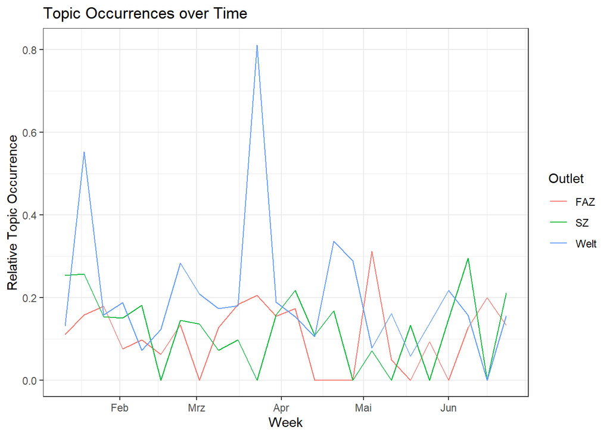

*Page Rank of Document: 0.04068159*

*Outlet: Welt*

**Warum Merkel der SPD die große Bühne überlässt**

*Während sich die SPD-Minister in ein Projekt nach dem anderen stürzen, bleibt es in der Union erstaunlich ruhig. Merkel überlässt Vizekanzler Gabriel die große Bühne. Dahinter steckt Kalkül.*

*Page Rank of Document: 0.03478769*

*Outlet: Welt*

**Diese Minister machen bei Schwarz-Rot Wind**

*Seit 100 Tagen regiert die große Koalition, erste Gesetze sind auf dem Weg. Doch nicht alle Minister in Merkels Kabinett sind gleich emsig. Die „Welt“ bewertet, wer sich besonders ins Zeug legt.*

*Page Rank of Document: 0.03319112*

*Outlet: Welt*

**Nur zum Weinkeller-Abend mag GroKo nichts sagen**

*Ob Energie, Rente oder G-8-Gipfel: Schwarz-Rot hat auf der Klausur in Meseberg alles abgedeckt. Auffällig wenig wollten die Teilnehmer aber darüber erzählen, wie das gegenseitige Kennenlernen verlief.*

*Page Rank of Document: 0.02332652*

*Outlet: Welt*

**Deutschland richtet 2015 G-8-Gipfel aus**

*Kanzlerin Merkel hat zum Abschluss der Kabinettsklausur in Meseberg verkündet, dass der G-8-Gipfel 2015 in Bayern stattfindet. Eine deutliche Warnung richtete sie an die ukrainische Regierung.*

*Page Rank of Document: 0.01880212*

*Outlet: Welt*

**In Meseberg müssen die Sozialdemokraten liefern**

*Bei einer Kabinettsklausur in Schloss Meseberg will sich Schwarz-Rot auf einen Fahrplan verständigen. Die wichtigsten Projekte verantwortet die SPD – ob Energiewende, Mindestlohn oder Mali-Einsatz.*

*Page Rank of Document: 0.0187309*

*Outlet: Welt*

**Gabriel braucht den Geist von Meseberg für sein Ziel**

*Gemeinsam ist das Schlüsselwort im Schloss. Kanzlerin und Vizekanzler mahnen, dass die Umsetzung des Koalitionsvertrages eine Aufgabe aller sei. Der SPD-Chef braucht Erfolge – aus einem guten Grund.*

*Page Rank of Document: 0.01684832*

*Outlet: Welt*

**Das ist die geheime Regierungsagenda der SPD**

*Energiewende, Rentenpaket, Mindestlohn: Ein 27 Seiten langes Papier listet die Großvorhaben der SPD auf. Das Dokument zeigt: Die SPD will sich nicht noch einmal von Merkels Union abkochen lassen.*

*Page Rank of Document: 0.01311294*

*Outlet: SZ*

**Jetzt einfach mal die Bürger fragen**

*Kanzlerin Merkel überrascht mit einer nebulösen Initiative. Ihr Vize Gabriel beruft sich auf einen Geist der Professionalität. Und Alexander Dobrindt darf sich über den G8-Gipfel in seinem Wahlkreis freuen. So war sie, die erste schwarz-rote Regierungsklausur in Schloss Meseberg.*

*Page Rank of Document: 0.0120209*

*Outlet: Welt*

**„Niemand sollte sinkende Strompreise erwarten“**

*SPD-Fraktionschef Thomas Oppermann glaubt nicht mehr an sinkende Kosten für Energie. Dafür gibt er Tipps für einen effizienten Lebensstil: Weniger heizen und die Waschmaschine richtig programmieren.*

*Page Rank of Document: 0.01058603*

*Outlet: Welt*

**Olaf Scholz will Elbphilharmonie 2017 einweihen**

*Hamburgs Erster Bürgermeister Olaf Scholz spricht im Interview über seine Verantwortung für Norddeutschland, den Wettbewerb mit dem Süden und sein Ziel, die Elbphilharmonie 2017 einzuweihen.*

# Topic: 15

## Top Terms: Werk, Brothers, Daimler, Dortmund, Übernahme, Kauf, Vorstandsvorsitzender, Analysten, M.M.Warburg, Großauftrag, Finanzvorstand, Nordex, Aktie, Schwellenländer, Börsengeschichte, Borussia, Ausgabepreis, Verein, KGaA, Pfad

## Topic Proportion: 9%

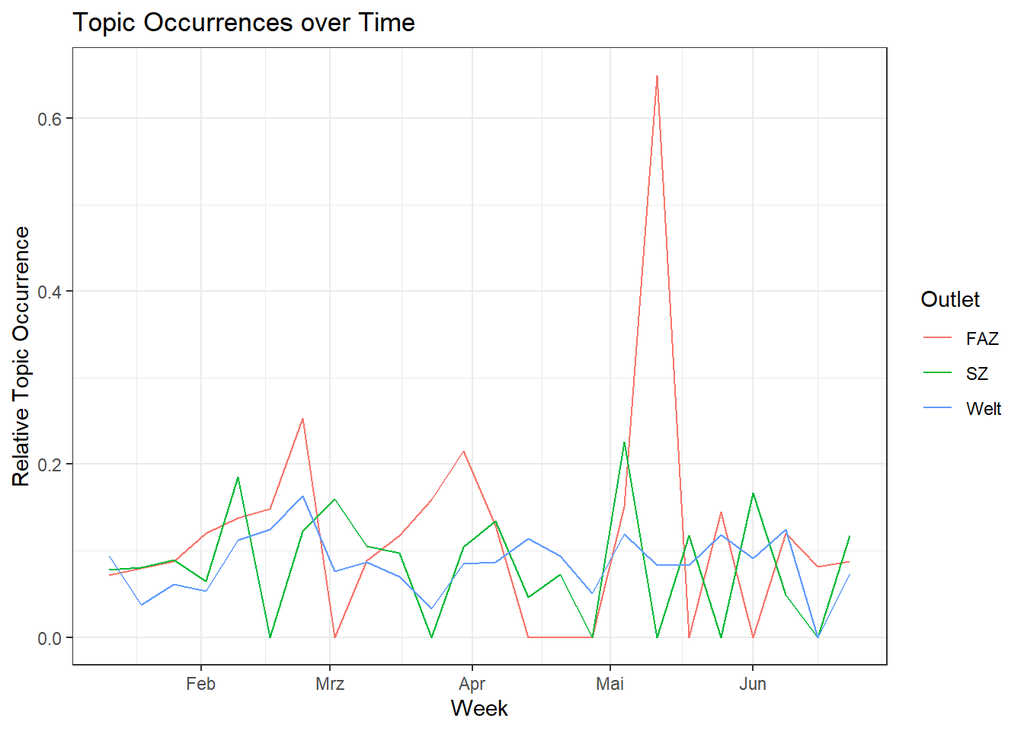

*Page Rank of Document: 0.05448889*

*Outlet: FAZ*

**Nebenwerte lohnen einen Blick für Anleger**

*Auf der Frühjahrskonferenz der Deutschen Vereinigung für Finanzanalyse und Asset Management (DVFA) diskutieren Unternehmer mit Analysten, Investoren und Journalisten. Wir haben sechs Vertreter von Nebenwerten am deutschen Aktienmarkt getroffen.*

*Page Rank of Document: 0.03581236*

*Outlet: FAZ*

**Die Rückkehr der Erneuerbaren**

*Wind- und Solaraktien waren tief gefallen. Jetzt schießen die Kurse in die Höhe und die Trendwende der Branche scheint geschafft. Denn die Welt will viel Öko.*

*Page Rank of Document: 0.02972319*

*Outlet: FAZ*

**Amerikas Autoverkäufe ziehen nach strengem Winter kräftig an**

*GM-Chefin Marry Barra stellt sich einem harten Verhör zu der tödlichen Pannenserie, Bundesverkehrsminister Dobrindt ruft Lufthansa und Piloten zu einer schnellen Einigung auf und der Wertpapierhandel der Deutsche Börse legt im März weiter zu.*

*Page Rank of Document: 0.01058277*

*Outlet: SZ*

**Diese Firmen profitieren vom Ökostrom-Rabatt**

*Busse und S-Bahnen, Lebensmittelhändler und Aluproduzenten: Mehr als 2000 Firmen dürfen sich die Öko-Umlage sparen und zahlen damit weniger für ihren Strom. Stattdessen steigt die Rechnung für die normalen Verbraucher. Nun zeigt der Staat, welche Unternehmen profitieren.*

*Page Rank of Document: 0.01050488*

*Outlet: SZ*

**Solarbranche fürchtet neuen Stellenabbau**

*Absturz trotz Rekordförderung: Deutschlands angeschlagene Solarbranche fürchtet einer Umfrage zufolge einen erneuten Einbruch - vor allem ein zentrales Vorhaben der Bundesregierung sorgt für Unruhe.*

*Page Rank of Document: 0.01040345*

*Outlet: FAZ*

**Regierungsberater wollen EEG abschaffen**

*Das wird Angela Merkel nicht gerne hören: Wissenschaftler raten, die Förderung von Ökostrom abzuschaffen. Sie helfe weder dem Klima, noch bringe sie technische Innovationen.*

*Page Rank of Document: 0.01038605*

*Outlet: FAZ*

**Union will nach neuen Energielieferanten suchen**

*Von Nigeria über Norwegen bis Qatar: Der stellvertretende Unionsfraktionsvorsitzende Fuchs will stärker über alternative Öl- und Gaslieferanten nachdenken. Auch Fracking kann er sich vorstellen.*

*Page Rank of Document: 0.008208919*

*Outlet: FAZ*

**Anstoß für neue Geschäftsfelder**

*Die Energieversorger suchen neue Geschäftsfelder jenseits der Lieferung von Strom, Gas und Wärme. Welche Leistungen und Produkte wünscht der Kunde? Wofür ist er bereit zu bezahlen? Dr. Werner Hitschler, Pfalzwerke, und Verbraucherschützer Dr. Holger Krawinkel richten den Blick auf aktuelle Herausforderungen und den Markt von morgen.*

*Page Rank of Document: 0.00797259*

*Outlet: Welt*

**Gabriels Energiereform bedroht 1000 Offshore-Jobs**

*Gewerkschafter fürchten, dass in den kommenden Wochen weitere 1000 Stellen in der Windkraftindustrie wegfallen. Grund dafür soll die ambitionierte Reform von Wirtschaftsminister Sigmar Gabriel sein.*

*Page Rank of Document: 0.007339374*

*Outlet: FAZ*

**Hilfe aus Brüssel im Ringen um EEG-Umlage**

*Rechenzentren brauchen sehr viel Strom, um arbeiten zu können. Die EEG-Umlage müssen sie trotzdem zahlen. Die EU stellt es dem Bund nun frei, diese in Frankfurt stark vertretene Branche zu entlasten. Doch der ziert sich.*

# Topic: 6

## Top Terms: E-Bass, Holzkorpus, Pickups, Gitarrenbauer, Warwick-Framus, Markneukirchen, Firmengründer, Wilfer, Vogtland, US-Instrumentenbauern, Fender, Gibson, Rickenbacker, Erfolgsrezepts, Musikindustrie, Englisch, Powered, Sustainably, Manufactured, Environment

## Topic Proportion: 8%

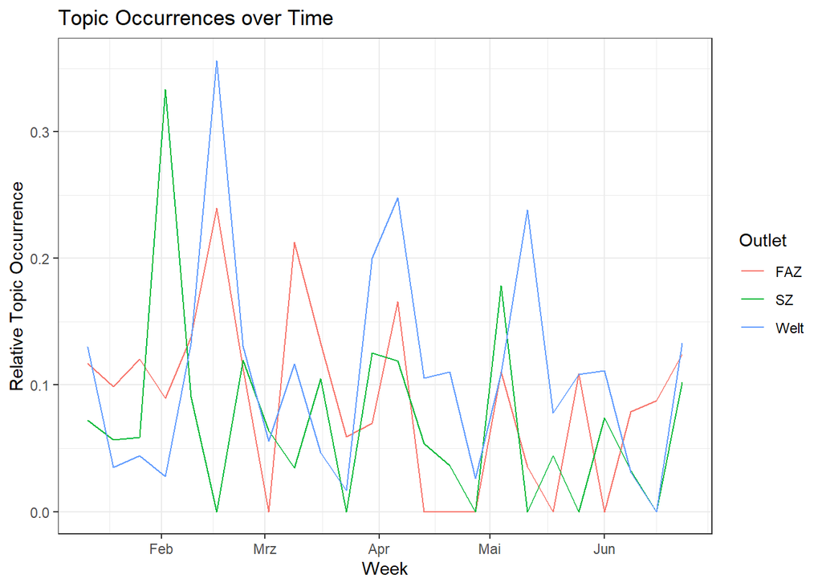

*Page Rank of Document: 0.05269037*

*Outlet: Welt*

**Die Energiewende ist Gift für Öko-Produkte**

*Das Szenario ist absurd: Die Ökostrom-Kosten werden in Deutschland zum Hindernis für nachhaltige Produktion. Am Dienstag entscheidet sich, welche Zukunft energieintensive Branchen hier noch haben.*

*Page Rank of Document: 0.02532877*

*Outlet: Welt*

**Gabriels Rabattschlacht mit Brüssel**

*Für die deutsche Industrie wäre es ein Desaster, wenn sie die volle Ökostrom-Umlage zahlen müsste. Doch das will die EU. Gibt es keinen Kompromiss, dürfte das die Unternehmen Milliarden Euro kosten.*

*Page Rank of Document: 0.01150358*

*Outlet: Welt*

**EU erlaubt Ökostrom-Rabatte für Metallindustrie**

*Deutschland und die EU haben sich im Streit über Ökostrom-Rabatte angenähert. EU-Kommissar Joaquín Almunia hat zugesagt, dass einige Branchen künftig von der EEG-Umlage befreit werden dürfen.*

*Page Rank of Document: 0.0114952*

*Outlet: Welt*

**EU knickt im Streit um Ökostrom-Rabatte ein**

*Das Horrorszenario ist vom Tisch: Brüssel lenkt im Beihilfestreit ein, die deutsche Industrie muss eine milliardenschwere Rückzahlung von Ökostrom-Rabatten wohl nicht mehr fürchten.*

*Page Rank of Document: 0.0105647*

*Outlet: SZ*

**Berlin und Brüssel streiten weiter um Ökostrom-Rabatte**

*“Schritt für Schritt nähern wir uns einem vernünftigen Ergebnis”: Im Streit um das Erneuerbare-Energien-Gesetz steht eine Einigung zwischen Wirtschaftsminister Gabriel und EU-Wettbewerbskommissar Almunia weiter aus. Die Zeit drängt - die Verhandlungen müssen kommende Woche abgeschlossen sein.*

*Page Rank of Document: 0.009570266*

*Outlet: FAZ*

**Hannelore Kraft: Ohne Strom-Rabatte wandert Industrie ab**

*Der EU-Kommission geht gegen die Ausnahmen von der Ökostrom-Förderung vor. NRW-Ministerpräsidentin Kraft warnt: Fallen die Ausnahmen, sind Hunderttausende Arbeitsplätze gefährdet.*

*Page Rank of Document: 0.009340246*

*Outlet: Welt*

**EU nimmt Deutschlands Industrie in die Zange**

*EU-Kommissar Oettinger zeigt zwar Verständnis für die Strompreis-Sorgen der deutschen Industrie. Doch das Gefeilsche um Ökostrom-Rabatte und „Sektor- und Strukturlisten“ geht jetzt erst richtig los.*

*Page Rank of Document: 0.009220418*

*Outlet: FAZ*

**Gabriel beißt in Brüssel mit Ökostromreform auf Granit**

*Sigmar Gabriel sagt das Berliner Energietreffen ab. Der Wirtschaftsminister konnte bei seinem Brüssel-Besuch „keine Grundlage für eine Diskussion erzielen“.*

*Page Rank of Document: 0.009187116*

*Outlet: FAZ*

**Regierung verteidigt Rabatte auf die Ökostromumlage**

*2014 werden mehr als 2700 Unternehmen von der EEG-Umlage befreit. Die Bundesregierung möchte weiter nicht darauf verzichten, energieintensive Industriebetriebe bei den Stromkosten zu entlasten.*

*Page Rank of Document: 0.008528625*

*Outlet: Welt*

**Der Mann, der die Energiewende auf Kurs bringen soll**

*Als Staatssekretär in Sigmar Gabriels Wirtschaftsministerium muss Rainer Baake die Energiewende neu gestalten. Die Personalie gilt als genialer Zug – denn Baake prägt die Energiepolitik seit Jahren.*

# Topic: 2

## Top Terms: Energiemarkt, Kostenblock, Reservekraftwerken, Errichtung, Netzentgelte, Reservekraftwerks, Gundremmingen, Hildegard, Netzentgelten, Kapazitätsmarktes, Energiewendekosten, Größenordnung, Großkraftwerken, Flucht, Zielwerte, Erkenntnis, Dach-Photovoltaik-Anlagen, Kleinkraftwerken, Stromverband, BDEW-Chefin

## Topic Proportion: 4%

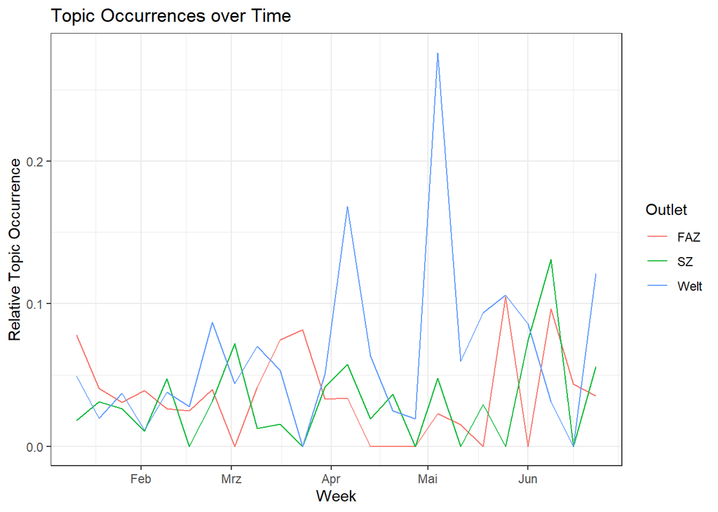

*Page Rank of Document: 0.05481616*

*Outlet: Welt*

**Eigenversorger treiben Strompreis in neue Höhen**

*Die Bundesregierung will die Ökostrom-Umlage „stabilisieren“. Doch nach Ansicht von Experten wird das nicht funktionieren, weil immer mehr Unternehmen und Bürger ihren Strom selbst produzieren.*

*Page Rank of Document: 0.04160827*

*Outlet: Welt*

**So viel kostet die Energiewende jeden von uns**

*Nun ist es amtlich: Das Ökostrom-Gesetz EEG hat den Strompreis laut Bundesnetzagentur erheblich ansteigen lassen. Zahlen tun vor allem die Privatverbraucher. Und: Energie wird noch deutlich teurer.*

*Page Rank of Document: 0.04093663*

*Outlet: Welt*

**Ökostrom-Reform ist der Anfang der Grausamkeiten**

*Das Subventionsregime für Ökostrom kollabiert unter seinem eigenen Gewicht. Die Bundesregierung hofft, mit einer Reform in letzter Minute den harten Aufprall in die ökonomische Realität abzufedern.*

*Page Rank of Document: 0.03934927*

*Outlet: Welt*

**Staatskraftwerk aus Angst vor Blackouts geplant**

*Dutzende Kraftwerke gehen vom Netz, weil sie nicht mehr rentabel sind. In Süddeutschland drohen im Winter Stromausfälle – weshalb es Planungen für den Bau eines ersten staatlichen Kraftwerks gibt.*

*Page Rank of Document: 0.01850787*

*Outlet: Welt*

**Verbraucher erzeugen ihren Strom immer öfter selbst**

*Viele Verbraucher stören sich an den steigenden Strompreisen. So sehr offenbar, dass immer mehr von ihnen selbst Energie erzeugen. Die Herstellung ist wegen geringerer Abgaben derzeit besonders lukrativ.*

*Page Rank of Document: 0.01796627*

*Outlet: FAZ*

**Verbraucher erzeugen immer mehr Strom selbst**

*Die Eigenstromerzeugung nimmt in Deutschland zu. Immer mehr Selbstverbraucher sparen sich die EEG-Umlage und Stromsteuern. Für die restlichen Kunden wird es dadurch teurer.*

*Page Rank of Document: 0.01053628*

*Outlet: FAZ*

**Unter Strom**

*Die geplante EEG-Reform stößt bei Umweltverbänden auf scharfe Kritik. Dagegen fordert die Stromindustrie ein Entgelt für die Versorgungssicherheit. Das ist unnötig und geht zu Lasten der Verbraucher.*

*Page Rank of Document: 0.009467465*

*Outlet: Welt*

**Das grüne Jobwunder fällt in sich zusammen**

*Erneuerbare Energien sollten Zehntausende Jobs schaffen. Doch trotz milliardenschwerer Beihilfen sinkt die Zahl der Arbeitsplätze. Sieben von zehn Stellen gibt es nur, solange Subventionen fließen.*

*Page Rank of Document: 0.009320554*

*Outlet: Welt*

**EEG-Umlage könnte kommendes Jahr sinken**

*Der Stromnetzbetreiber 50Hertz rechnet für 2015 mit einer sinkenden EEG-Umlage. Noch liegt sie auf einem Rekordniveau. Verbraucher können aber nur aufatmen, wenn das Wetter wieder schlechter wird.*

*Page Rank of Document: 0.009071359*

*Outlet: Welt*

**„Kommission will Deutschland in Geiselhaft nehmen“**

*Die EU-Kommission vergleicht deutsche Ökostrom-Beihilfen mit einem rechtswidrigen „Zoll“ und stellt sie plötzlich in Frage. Wirtschaftsminister Gabriel nennt das ein „Foulspiel“ gegenüber Deutschland.*

# Topic: 13

## Top Terms: Monstertrasse, Geschäftsgrundlage, Amprion, Meitingen, Augsburg, Lauchstädt, Stromautobahnen, Mast, Alleingang, Netzstabilität, Süd-Ost, Gleichstrompassage, Regierungsparteien, Stromautobahn, Hemmung, Volte, Plenarsaal, Kleinstrategen, Verwirrung, Rückgratlosigkeit

## Topic Proportion: 3%

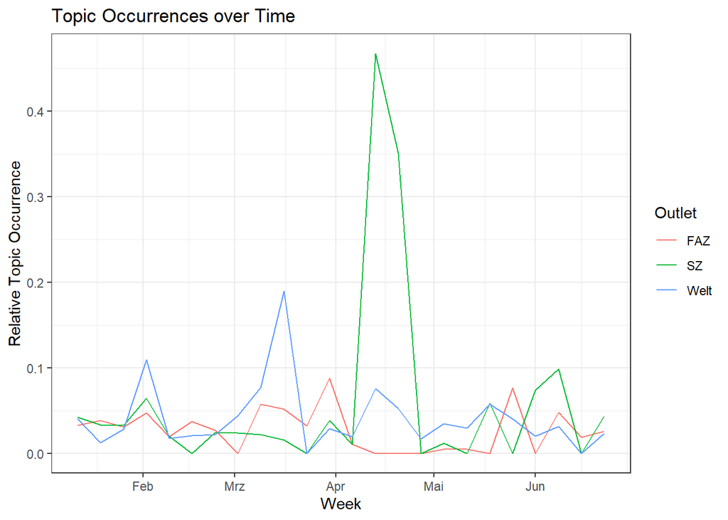

*Page Rank of Document: 0.07113752*

*Outlet: SZ*

**Bundesregierung im Trassenkampf gegen Seehofer**

*Keine neuen Stromautobahnen, dafür ein energieautarkes Bayern - so stellt sich Horst Seehofer die Energiewende vor. Jetzt reicht es der Bundesregierung. In einem Papier erteilt sie den bayerischen Alleingängen erstmals offen eine Abfuhr.*

*Page Rank of Document: 0.06030681*

*Outlet: Welt*

**Warum Seehofer allzeit auf Krawall gebürstet ist**

*Der überraschende Widerstand Bayerns gegen neue Stromtrassen ist konsequent: Für den Wahlerfolg setzt CSU-Chef Horst Seehofer immer viel aufs Spiel. Und die Partei steht aktuell vor einer Kraftprobe.*

*Page Rank of Document: 0.04921178*

*Outlet: FAZ*

**Die Problemtrassen**

*Die Länder haben kaum Möglichkeiten, den Netzausbau für die Energiewende zu beeinflussen. Doch Bayern zeigt, wie es geht. Das bringt Verzögerungen mit sich.*

*Page Rank of Document: 0.03064613*

*Outlet: Welt*

**Seehofer bricht im Trassenstreit die eigenen Regeln**

*Der CSU-Vorsitzende hat es eilig. Er beerdigt schon jetzt die Pläne für eine neue Stromtrasse aus Sachsen-Anhalt nach Bayern. Seine Wirtschaftsministerin Ilse Aigner widerspricht.*

*Page Rank of Document: 0.03050368*

*Outlet: SZ*

**Hochspannung im Trassenstreit**

*Mit allen Mitteln will er dagegen kämpfen: Horst Seehofer wehrt sich gegen den Bau von Stromtrassen in Bayern. Doch die Netzbetreiber halten an ihren Plänen fest. Und auch das Wirtschaftsministerium verpasst dem Ministerpräsidenten einen Dämpfer.

*Page Rank of Document: 0.0203944*

*Outlet: Welt*

**Seehofer rüffelt „Geschwätz“ von Oettinger**

*Der bayerische Ministerpräsident Seehofer stellt erneut zentrale Punkte der Energiewende infrage. Er will den Verlauf von Stromtrassen überprüfen lassen – und teilt gegen EU-Kommissar Oettinger aus.*

*Page Rank of Document: 0.01710532*

*Outlet: FAZ*

**Darum geht es beim Energie-Gipfel im Kanzleramt**

*Im Kanzleramt wird über Gabriels Gesetzentwurf für ein „EEG 2.0“ verhandelt. Gesucht wird ein Kompromiss zwischen Industrie, Ländern und Öko-Interessen. Ob die Stromkunden am Ende auch etwas davon haben?*

*Page Rank of Document: 0.01083993*

*Outlet: Welt*

**EEG-Umlage könnte kommendes Jahr sinken**

*Der Stromnetzbetreiber 50Hertz rechnet für 2015 mit einer sinkenden EEG-Umlage. Noch liegt sie auf einem Rekordniveau. Verbraucher können aber nur aufatmen, wenn das Wetter wieder schlechter wird.*

*Page Rank of Document: 0.01043555*

*Outlet: FAZ*

**Der Süden wehrt sich gegen das „Diktat des Nordens“**

*An diesem Dienstag verhandelt Bundeskanzlerin Merkel mit den Ministerpräsidenten über die EEG-Reform. Ihr Leitsatz: Die Summe der Einzelinteressen ist nicht das Allgemeinwohl. Das sieht der bayerische Ministerpräsident Seehofer ganz anders.*

*Page Rank of Document: 0.01040665*

*Outlet: FAZ*

**Ramsauer stellt sich gegen Seehofer**

*Was wird aus der Energiewende? CSU-Vize Ramsauer warnt vor einem Moratorium des Netzausbaus und greift den Parteichef an.*

# Topic: 31

## Top Terms: Fördersysteme, Koalitionsfraktionen, Ruhr, Angeln, EuGH, Generalanwalt, Yves, Bot, Streitpunkte, Rhein, Fördersystems, Zollschranke, Horrorgemälde, Ermäßigungen, Übergang, Vize-Fraktionschef, Gegenstimmen, Formsache, Mammut-Reform, Reformschritten

## Topic Proportion: 2%

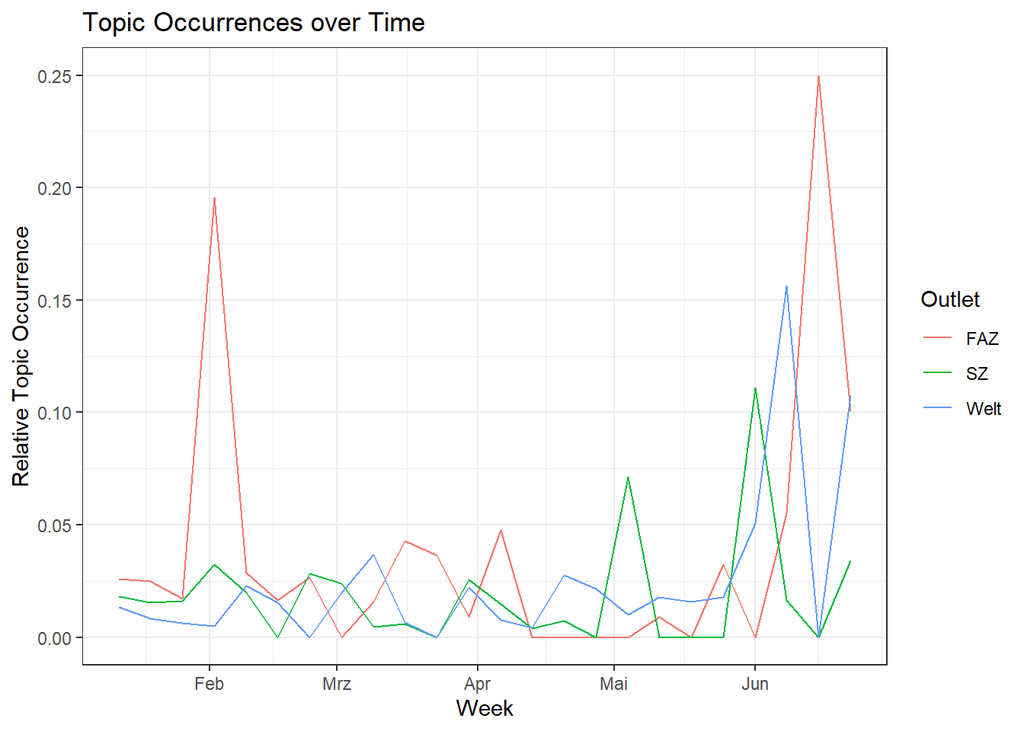

*Page Rank of Document: 0.06892985*

*Outlet: Welt*

**Die wichtigsten Fakten zur Ökostrom-Reform**

*Muss jetzt jeder mit einer Solaranlage auf dem Dach EEG-Umlage zahlen? Wird Strom billiger? Droht die Wirtschaft abzuwandern? Die „Welt“ gibt Antworten auf die wichtigsten Fragen zur EEG-Reform.*

*Page Rank of Document: 0.05819567*

*Outlet: FAZ*

**Merkel warnt vor Zerschießung des EEG**

*Die Bundeskanzlerin ärgert sich über die EU: Brüssel dürfe jahrelange Fördersysteme nicht in Frage stellen, ohne Übergänge zu schaffen.*

*Page Rank of Document: 0.03959882*

*Outlet: FAZ*

**Nordrhein-Westfalen zahlt Bayerns Ökostrom**

*Das arme Ruhrgebiet trägt mit immer mehr Geld zur Energiewende bei. Die Milliarden kommen vor allem Landwirten im Norden und dem reichen Bayern zu Gute.*

*Page Rank of Document: 0.02674365*

*Outlet: FAZ*

**EU torpediert die EEG-Reform**

*Deutschland wollte mit der Ökostromreform den Preisanstieg bremsen. Doch jetzt verlangt Brüssel, dass Deutschland die Vergütung auch ausländischen Erzeugern zahlt.*

*Page Rank of Document: 0.023583*

*Outlet: Welt*

**„Kommission will Deutschland in Geiselhaft nehmen“**

*Die EU-Kommission vergleicht deutsche Ökostrom-Beihilfen mit einem rechtswidrigen „Zoll“ und stellt sie plötzlich in Frage. Wirtschaftsminister Gabriel nennt das ein „Foulspiel“ gegenüber Deutschland.*

*Page Rank of Document: 0.02351392*

*Outlet: FAZ*

**Gabriel: EU zerstört Ökostromförderung**

*Mit bisher nicht gekannter Wucht sind Berlin und Brüssel aneinander geraten. Der Grund ist die Reform des Ökostrom-Fördergesetzes EEG.*

*Page Rank of Document: 0.01658083*

*Outlet: FAZ*

**Berlin will mit dem Kopf durch die Wand**

*Union und SPD lassen es auf eine Kraftprobe mit der EU ankommen. Brüssel will die deutsche EEG-Gesetzesnovelle nicht akzeptieren, doch die Bundesregierung bleibt stur.*

*Page Rank of Document: 0.0157428*

*Outlet: Welt*

**Deutsche verschmähen einst geliebte Solaranlagen**

*Es war eine idiotensichere Geldanlage: Für Solarmodule auf dem Dach garantierte der Staat eine Top-Rendite. Jetzt, wo die Fördersätze gekürzt sind, bricht die Nachfrage ein.*

*Page Rank of Document: 0.01527721*

*Outlet: FAZ*

**Wer gewinnt, wer verliert?**

*An diesem Freitag hat der Bundestag die Reform der Ökostromförderung beschlossen. Sie tritt im August in Kraft. Die wichtigsten Fragen und Antworten zum neuen EEG.*

*Page Rank of Document: 0.01163492*

*Outlet: FAZ*

**Todesstoß für Ökostromförderung**

*Offenbar braucht es die EU, um den Deutschen auf teure Weise klarzumachen, dass das Subventionsmonster EEG unbezahlbar ist.*

# Topic: 11

## Top Terms: Gabriel

## Topic Proportion: 2%

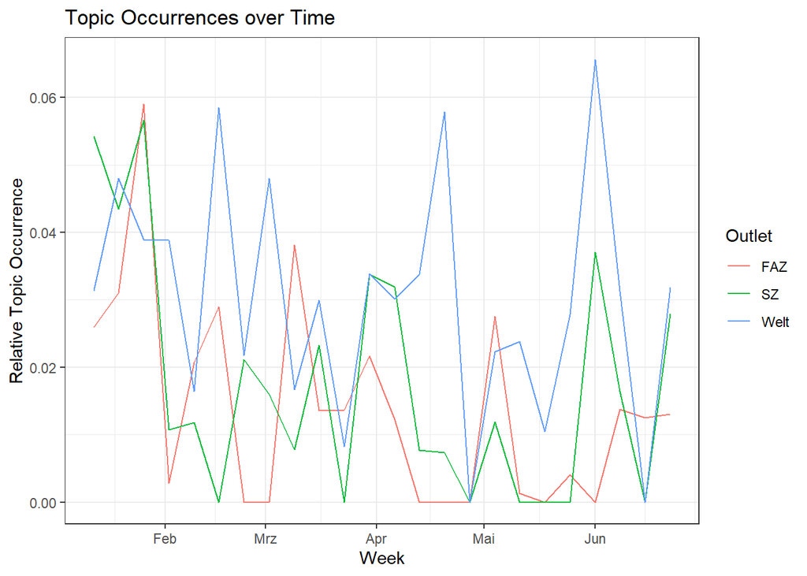

*Term Frequency of Document: 0.1009174*

*Outlet: Welt*

**Gabriel entdeckt den Industriestolz der SPD wieder**

*Mit der EEG-Reform hat Wirtschaftsminister Sigmar Gabriel einen Meilenstein erreicht – womöglich auf dem Weg ins Kanzleramt. Jetzt beweist er sich als wirtschaftsfreundlicher Sozialdemokrat.*

*Term Frequency of Document: 0.09615385*

*Outlet: Welt*

**Wie sich Sigmar Gabriel mit dem RWE-Chef anlegt**

*Energieminister Gabriel hat seine erste Grundsatzrede vor der Branche gehalten. Für seine Reformpläne erhielt er viel Applaus. In einem Punkt gerieten sich Minister und Manager aber doch in die Haare.*

*Term Frequency of Document: 0.09302326*

*Outlet: Welt*

**Sigmar Gabriel mausert sich zum Liebling der Bosse**

*Rente mit 63, Mindestlohn und Zurückdrehen der Arbeitsmarktreformen: Eigentlich müssten viele Firmen mit Wirtschaftsminister Sigmar Gabriel (SPD) unzufrieden sein. Doch tatsächlich kommt er gut an.*

*Term Frequency of Document: 0.08713693*

*Outlet: SZ*

**Gabriel spielt das Merkel-Echo**

*Spricht da der heimliche Kanzler? SPD-Chef Sigmar Gabriel wirbt im Bundestag für seine Energiewende. Die Grünen umschmeichelt er, ebenso CSU-Verkehrsminister Dobrindt. Aus seiner Partei muss er sich jedoch anhören, er betreibe Planwirtschaft.*

*Term Frequency of Document: 0.0754717*

*Outlet: Welt*

**Gabriel will Wirtschaft bei Energiewende schonen**

*Bundeswirtschaftsminister Sigmar Gabriel (SPD) will das Erneuerbare-Energien-Gesetz ganz schnell ändern. Vor allem, weil die deutsche Wirtschaft am Rande ihrer Möglichkeiten angekommen ist.*

*Term Frequency of Document: 0.07438017*

*Outlet: SZ*

**Diplomatie auf Kosten der Verbraucher**

*Bei der EEG -Reform will Wirtschaftsminister Gabriel es allen recht machen. Die Industrie behält ihre Rabatte, die Ökobranche ihre Förderung. Der Verbraucher zahlt. Aber der entscheidet am Ende auch über seinen Erfolg als Energieminister.*

*Term Frequency of Document: 0.07359307*

*Outlet: Welt*

**Energie-Reform – Gabriel verspricht Korrekturen**

*Wirtschaftsminister Gabriel hat im Bundestag sein Energiewende-Konzept verteidigt, schloss Nachbesserungen aber nicht aus. SPD-Ministerpräsident Albig unterstellte der Reform sozialistische Züge.*

*Term Frequency of Document: 0.06818182*

*Outlet: FAZ*

**Gabriel: Ökostrom-Rabatte kein Industrielobbyismus**

*Das Bundeskabinett billigt die Rabatte für Unternehmen bei der Ökostrom-Umlage. Wirtschaftsminister Gabriel Gabriel schütze damit vor allem die Industrie, kritisiert die Opposition. Doch Gabriel wehrt sich gegen die Vorwürfe.*

*Term Frequency of Document: 0.06779661*

*Outlet: FAZ*

**SPD-Ministerpräsident gegen Gabriels Ökostromreform**

*Bundeswirtschaftsminister Gabriel (SPD) will den Windkraft-Ausbau drosseln. Dafür erntet er Kritik aus den eigenen Reihen: Der Plan sei „volkswirtschaftlich unsinnig“, findet der schleswig-holsteinische Ministerpräsident Albig.*

*Term Frequency of Document: 0.06666667*

*Outlet: Welt*

**Albig nennt Gabriels Ökostrom-Pläne „unsinnig“**

*Die geplante Drosselung des Windkraftausbaus führt zu internen Unstimmigkeiten in der SPD. Denn Schleswig-Holsteins Ministerpräsident Albig kritisiert den Vorschlag von Gabriel als „unnötig teuer“.*

# Topic: 1

## Top Terms: Bundestagspräsident, Norbert, Lammert, Plenum, Abrissbirne, Fraktionsvize, Aken, Verdienst, Zwischenrufe, vonseiten, Industriegesellschaft, Sicherung, Anregung, Oppositionspolitiker, Bundeskanzler, Freitagvormittag, Regierungsbänke, Mikrofon, stillen, Reichstagsgebäude

## Topic Proportion: 2%

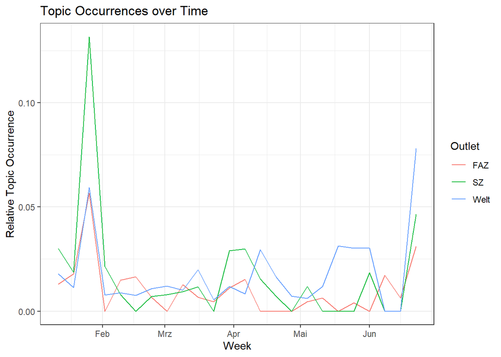

*Page Rank of Document: 0.08977468*

*Outlet: SZ*

**Gabriel spielt das Merkel-Echo**

*Spricht da der heimliche Kanzler? SPD-Chef Sigmar Gabriel wirbt im Bundestag für seine Energiewende. Die Grünen umschmeichelt er, ebenso CSU-Verkehrsminister Dobrindt. Aus seiner Partei muss er sich jedoch anhören, er betreibe Planwirtschaft.*

*Page Rank of Document: 0.07883707*

*Outlet: Welt*

**Gabriel drückt Energiereform durchs Parlament**

*Mit einer breiten Mehrheit von 454 Stimmen billigt die Koalition das EEG-Gesetz. Kritik der Opposition weist Wirtschaftsminister Sigmar Gabriel (SPD) als „Klamauk“ zurück.*

*Page Rank of Document: 0.06970677*

*Outlet: Welt*

**Energie-Reform – Gabriel verspricht Korrekturen**

*Wirtschaftsminister Gabriel hat im Bundestag sein Energiewende-Konzept verteidigt, schloss Nachbesserungen aber nicht aus. SPD-Ministerpräsident Albig unterstellte der Reform sozialistische Züge.*

*Page Rank of Document: 0.0369523*

*Outlet: FAZ*

**Bundestag gibt grünes Licht für Ökostromreform**

*Die Koalition bringt ihre heiß umkämpfte Ökostromreform sicher durch das Parlament. Gejubelt wird jedoch kaum.*

*Page Rank of Document: 0.02962501*

*Outlet: FAZ*

**Gabriel bietet Kritikern Zusammenarbeit an**

*Bundeswirtschaftsminister Sigmar Gabriel hat Einwände gegen seine Pläne zur Reform der Ökosteuer zurückgewiesen. Seinen Kritikern bot er eine „konstruktive“ Zusammenarbeit an.*

*Page Rank of Document: 0.02287628*

*Outlet: SZ*

**Diplomatie auf Kosten der Verbraucher**

*Bei der EEG -Reform will Wirtschaftsminister Gabriel es allen recht machen. Die Industrie behält ihre Rabatte, die Ökobranche ihre Förderung. Der Verbraucher zahlt. Aber der entscheidet am Ende auch über seinen Erfolg als Energieminister.*

*Page Rank of Document: 0.01842328*

*Outlet: Welt*

**Staat verdient Milliarden durch steigende Strompreise**

*Mit mehr als 1,6 Milliarden Euro Einnahmen aus der Umsatzsteuer auf steigende Strompreise kann der Bund in diesem Jahr rechnen. Die Linke fordert, den Stromkunden das Geld zurückzugeben.*

*Page Rank of Document: 0.01555282*

*Outlet: Welt*

**Gabriel liefert sich Schlagabtausch mit EU**

*Bundeswirtschaftsminister Sigmar Gabriel greift die EU-Kommission scharf an: Die wolle mit ihren jüngsten Querschüssen das Ökostrom-Gesetz EEG „zerstören“. Die Retourkutsche aus Brüssel kam prompt.*

*Page Rank of Document: 0.01259054*

*Outlet: FAZ*

**Gabriel will Ökostromumlage später senken**

*Wirtschaftsminister Sigmar Gabriel reagiert auf die Kritik von Investoren und Bundesländern: Die Ökostromumlage soll später sinken. Das steht in einem Entwurf, der der F.A.Z. vorliegt.*

*Page Rank of Document: 0.01055735*

*Outlet: SZ*

**Länder schwächen Gabriels Reformpläne ab**

*Bei einem Treffen im Kanzleramt verständigen sich die Ministerpräsidenten und die Bundesregierung in wesentlichen Punkten auf eine Reform der Ökostrom-Förderung. Die Länder können die geplanten Einschnitte bei der Windenergie entschärfen.*

# Topic: 16

## Top Terms: Quadratur, Amtszimmer, Rathausmarkt, Norddeutschlands, Serie, Zugpferd, Hansestadt, Arroganz, Ministerpräsidenten-Kollegen, Überheblichkeit, Staatsgrenze, Theater, Stadtstaat, Metropolregion, Schlagkraft, Visier, Nord-Regierungschefs, Verkehrsinfrastruktur, rings, Instandhaltung

## Topic Proportion: 2%

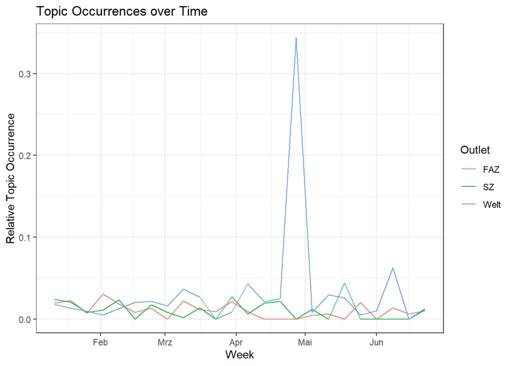

*Page Rank of Document: 0.09486285*

*Outlet: Welt*

**Olaf Scholz will Elbphilharmonie 2017 einweihen**

*Hamburgs Erster Bürgermeister Olaf Scholz spricht im Interview über seine Verantwortung für Norddeutschland, den Wettbewerb mit dem Süden und sein Ziel, die Elbphilharmonie 2017 einzuweihen.*

*Page Rank of Document: 0.07076619*

*Outlet: Welt*

**Industrie erbost über Schein-Reform des EEG**

*Die EEG-Reform soll die Ökostrom-Branche dem freien Spiel von Angebot und Nachfrage aussetzen. Augenwischerei, kritisiert die Industrie. Die geplante Novelle wirke lediglich wie eine Schein-Reform.*

*Page Rank of Document: 0.02487621*

*Outlet: Welt*

**Bürgermeister Scholz glaubt an Energiewende**

*Hamburgs Bürgermeister betrachtet die Reform als notwendige Voraussetzung für das Gelingen der Energiewende. Umweltschützer demonstrieren am Rande der Ministerpräsidentenkonferenz.*

*Page Rank of Document: 0.01199212*

*Outlet: Welt*

**Neue Ökostrom-Regel könnte Bahnfahren verteuern**

*Die Deutsche Bahn soll künftig für die Energiewende stärker zur Kasse gebeten werden. Dagegen poltert nun die Schienen-Lobby: Zusätzliche Kosten würden „unweigerlich“ auf die Fahrpreise umgelegt.*

*Page Rank of Document: 0.011385*

*Outlet: FAZ*

**Energieintensive Betriebe werden geschont**

*Bundesregierung und die EU-Kommission haben sich auf einen Kompromiss bei den Ökostromrabatten für die Industrie geeinigt. Wirtschaftsminister Gabriel verkündet nun erste Details.*

*Page Rank of Document: 0.0113134*

*Outlet: SZ*

**Querschüsse von der großen Koalition**

*Die neuesten Pläne aus Berlin könnten die Energiewende im Landkreis weiter zurückwerfen*

*Page Rank of Document: 0.01128105*

*Outlet: FAZ*

**Der Süden wehrt sich gegen das „Diktat des Nordens“**

*An diesem Dienstag verhandelt Bundeskanzlerin Merkel mit den Ministerpräsidenten über die EEG-Reform. Ihr Leitsatz: Die Summe der Einzelinteressen ist nicht das Allgemeinwohl. Das sieht der bayerische Ministerpräsident Seehofer ganz anders.*

*Page Rank of Document: 0.01119122*

*Outlet: Welt*

**Gabriel will Wirtschaft bei Energiewende schonen**

*Bundeswirtschaftsminister Sigmar Gabriel (SPD) will das Erneuerbare-Energien-Gesetz ganz schnell ändern. Vor allem, weil die deutsche Wirtschaft am Rande ihrer Möglichkeiten angekommen ist.*

*Page Rank of Document: 0.01057692*

*Outlet: SZ*

**Teurer Kompromiss**

*Bundesregierung und Länder feiern sich und ihre Einigung beim Strom-Gipfel. Aber geht das - Zufriedenheit auf allen Seiten? Wer profitiert, wer hat das Nachsehen? Die wichtigsten Fragen und Antworten zur geplanten Reform des Erneuerbare-Energien-Gesetzes.*

*Page Rank of Document: 0.01044834*

*Outlet: SZ*

**Länder üben harsche Kritik an Gabriels Ökostrom-Plänen**

*“Volkswirtschaftlich unsinnig”, “starke Zweifel”, “unzureichend”: Bundeswirtschaftsminister Gabriel stößt mit seinem Reformvorschlag für die Energiewende auf Widerstand - auch aus SPD-geführten Ländern.*